# Modern analogue technique

To run this .Rmd file, you have to change file paths in lines *134* and *290*.

## 1 Dissimilarity / distance metrics

The modern analogue technique is a statistical technique used to reconstruct past environments and climates. To reconstruct past environments, we need three data sets:

- modern species assemblages
- modern environmental variables
- fossil species assemblages

The basic assumption of the modern analogue technique is that similar environments result in similar species assemblages. In a first step a fossil species assemblage is compared to all modern species assemblages. Then the environmental values associated with the *k* closest *modern analogues* are averaged to infer past environmental conditions.

The distance/dissimilarity metric used to compare modern and fossil species assemblages is crucial. In a first step we will compare three distance/dissimilarity metrics:

- Euclidean distance
- Chord distance
- Bray-Curtis distance

We will test these metrics on the the North American Modern Pollen Database (Whitmore et al. 2005). These modern data are available from the *analogue* r-package by Gavin Simpson.

```r
  library(analogue)
  library(rioja)
  library(vegan)
  library(maps)
```

```r
  data(Pollen)
  data(Climate)
  data(Location)
  head(Pollen)
```

```
##   ABIES ACNEGUNA ACPENSYL ACRUBRUM ACSACNUM ACSACRUM ACERX ALCRISPA
## 1     0        0        0        0        0        0     2      176
## 2     4        0        0        0        0        0     0        0
## 3     4        0        0        0        0        0     0       16
## 4     0        1        0      102        0        0     0        0
## 5     1        0        0        0        0       14     0        6
## 6    48        0        0        0        0        2     1       19
##   ALRUBRA ALRUGOSA ALNUSX AMBROSIA AMORPHA ANACARDI APIACEAE AQUIFOLI
## 1       0        0      0        5       0        0        0        0
## 2       0        0      3        0       0        0        0        0
## 3       0        2      0        1       0        0        0        0
## 4       0        0     80       73       0        0        0        0
## 5       0        2      0        1       0        0        0        0
## 6       0       34      0        9       0        0        0        0
##   ARCEUTHOBI ARECACEAE ARMERIA ARTEMISIA ASTERX ASTERCICHO BETULA
```

[output cut: 111 more lines]

```r
  head(Climate)
```

```
##   Sitename   lon   lat  tapr tmay tjun tjul taug tsep toct tnov  tdec pjan
## 1    -23.1 -23.6 -20.5 -13.1 -4.0  1.5  5.8  5.6  2.2 -3.1 -8.7 -17.9   21
## 2    -12.1 -10.3  -4.3   4.2 11.4 15.7 18.9 17.5 12.7  6.6  0.1  -8.6   62
## 3    -13.7 -13.2  -8.6  -3.0  2.1  6.6 10.9 10.9  7.3  2.2 -2.7  -9.7  105
## 4      1.6   3.8   9.3  14.2 18.5 22.7 24.5 24.0 20.6 14.4  9.2   4.0  124
## 5    -10.7  -9.1  -3.0   5.3 12.4 17.4 20.2 18.7 13.9  7.6  1.0  -7.4   76
## 6    -15.0 -14.1  -8.1  -0.6  6.6 12.7 15.4 13.8  9.0  3.1 -4.2 -12.1  101
##   pfeb pmar papr pmay pjun pjul paug psep poct pnov pdec       tave tmax
## 1   19   19   22   25   43   63   59   43   40   33   23 -8.2416667 25.8
## 2   51   63   67   77   94   95  101  114   93   89   73  4.3166667 37.2
## 3   85  106   81   67   92   92   99   90   89   95  105 -0.9083333 31.9
## 4  116  147  115  129  107  124   92  101   81  118  136 13.9000000 40.4
## 5   65   74   78   82   93   95  104   94   84   99   96  5.5250000 37.0
## 6   86  105  103  122  124  128  125  118  108  116  122  0.5416667 33.6
##    tmin   gdd0   gdd5  mtco mtwa annp
## 1 -45.4  427.2   25.6 -23.6  5.8  410
## 2 -43.2 2632.6 1588.3 -12.1 18.9  979
## 3 -37.1 1188.2  446.8 -13.7 10.9 1106
## 4 -25.5 5096.2 3410.9   1.6 24.5 1390
## 5 -38.6 2911.0 1824.9 -10.7 20.2 1040
## 6 -45.0 1820.8  957.2 -15.0 15.4 1358
```

```r
  head(Location)
```

```
##   Latitude Longitude
## 1   60.979   -69.992
## 2   46.050   -79.200
## 3   52.517   -57.033
## 4   36.033   -85.500
## 5   45.543   -73.311
## 6   47.482   -70.685
```

The first three columns of the *climate* data seem odd. Latitudes and longitudes are different from lats and lons found in *location* and site names are real numbers and not characters. Additionally, January through March temperatures are missing. I therefore assume that the first three columns of *climate* are January through March temperatures. The pollen data are given as count data and contain *NAs*. To compare species assemblages, we need species composition / proportions and not absolute abundances. We therefore have to transform count data to proportions.

```r
  colnames(Climate)[1:3] <- c('tjan','tfeb','tmar')
  Pollen.corrected <- replace(Pollen,is.na(Pollen),0)
  pollen.prop <- Pollen.corrected/rowSums(Pollen.corrected)
```

To get an overview of the North American Modern Pollen Database we can make a map of pollen samples

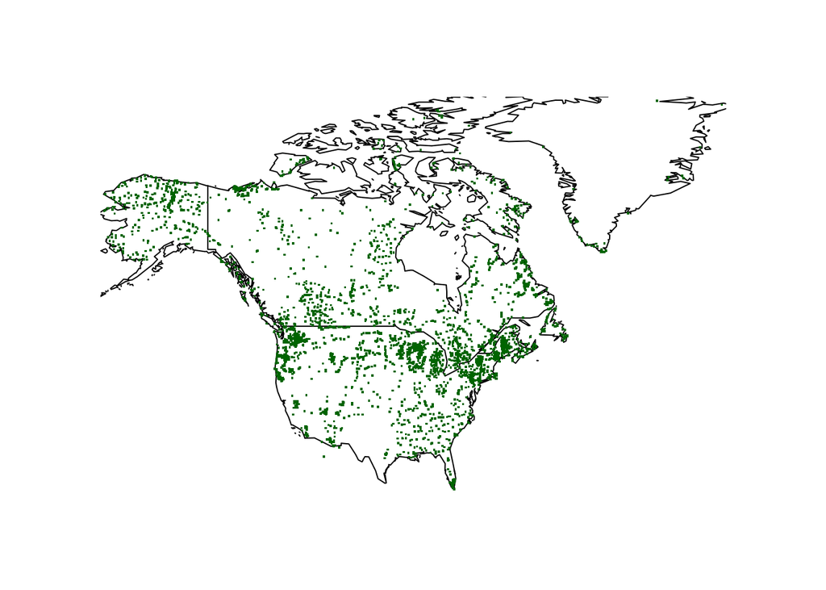

```r
lon <- Location$Longitude
lat <- Location$Latitude
map(regions=c('USA','Canada','Greenland'),xlim=c(range(lon)),ylim=range(lat))
points(lon,lat,pch = 15,cex =0.25,col='darkgreen')
```

Lets look at dissimilarities with the NAMPD. We will compare the distance / dissimilarity among the northernmost and southernmost sample, two spatially close samples and 1000 distances / dissimilarities between randomly drawn samples. Keep in mind that the minimum of all dissimilarity metrics is 0 while the chord distance has a maximum of 1.4142136 and the Bray-Curtis distance has a maximum of 1.

```r
nm.pollen <- pollen.prop[which.max(lat), ]
sm.pollen <- pollen.prop[which.min(lat), ]
pollen.sn <- rbind(nm.pollen, sm.pollen)
pollen.prop.lat.order <- pollen.prop[order(lat), ]


dist.sn.chord <- analogue::distance(pollen.sn, method = "chord")
dist.sn.euclidean <- analogue::distance(pollen.sn, method = "euclidean")
dist.sn.bray <- analogue::distance(pollen.sn, method = "bray")

dist.sn <- data.frame(chord = dist.sn.chord[1, 2], euclidean = dist.sn.euclidean[1,
    2], bray = dist.sn.bray[1, 2])

dist.adj.chord <- analogue::distance(pollen.prop.lat.order[2:3, ], method = "chord")
dist.adj.euclidean <- analogue::distance(pollen.prop.lat.order[2:3, ], method = "euclidean")
dist.adj.bray <- analogue::distance(pollen.prop.lat.order[2:3, ], method = "bray")

dist.adj <- data.frame(chord = dist.adj.chord[1, 2], euclidean = dist.adj.euclidean[1,
    2], bray = dist.adj.bray[1, 2])
#---------------------------------------------------------------------------------------------
# 1000 random distances
#---------------------------------------------------------------------------------------------
dist.rand <- replicate(1000, {
    sample.nr <- sample(1:ncol(Pollen), 2, replace = FALSE)
    pollen.sample <- pollen.prop[sample.nr, ]
    dist.r.chord <- analogue::distance(pollen.sample, method = "chord")
    dist.r.euclidean <- analogue::distance(pollen.sample, method = "euclidean")
    dist.r.bray <- analogue::distance(pollen.sample, method = "bray")
    data.frame(chord = dist.r.chord[1, 2], euclid = dist.r.euclidean[1, 2],
        bray = dist.r.bray[1, 2])
})

dist.rand.matrix <- matrix(unlist(dist.rand), nrow = 1000, ncol = 3, byrow = TRUE)
colnames(dist.rand.matrix) <- c("chord", "euclidean", "bray")

dist.rand.quantiles <- apply(dist.rand.matrix, 2, function(x) quantile(x, probs = c(0.025,
    0.25, 0.5, 0.75, 0.975)))

round(rbind(dist.adj, dist.rand.quantiles, dist.sn), 3)
```

```
##       chord euclidean  bray
## 1     0.721     0.467 0.554
## 2.5%  0.542     0.219 0.342
## 25%   0.840     0.385 0.585
## 50%   0.980     0.504 0.708
## 75%   1.137     0.607 0.822
## 97.5% 1.319     0.867 0.960
## 11    1.293     0.767 0.952
```

Let’s compare the three dissimilarity metrics based on dissimilarities among all samples.

```r
distance.all.chord <- dist(sqrt(pollen.prop), diag = FALSE, upper = FALSE, method = "euclidean")
distance.all.euclid <- dist(pollen.prop, diag = FALSE, upper = FALSE, method = "euclidean")
distance.all.bray <- vegan::vegdist(pollen.prop, diag = FALSE, upper = FALSE,
    method = "bray")


summary(distance.all.chord)
```

```
##    Min. 1st Qu.  Median    Mean 3rd Qu.    Max.
##  0.0000  0.9222  1.0914  1.0571  1.2262  1.4142
```

```r
summary(distance.all.bray)
```

```
##    Min. 1st Qu.  Median    Mean 3rd Qu.    Max.
##  0.0000  0.6492  0.7937  0.7556  0.8966  1.0000
```

```r
summary(distance.all.euclid)
```

```
##    Min. 1st Qu.  Median    Mean 3rd Qu.    Max.
##  0.0000  0.4766  0.6034  0.6072  0.7321  1.3760
```

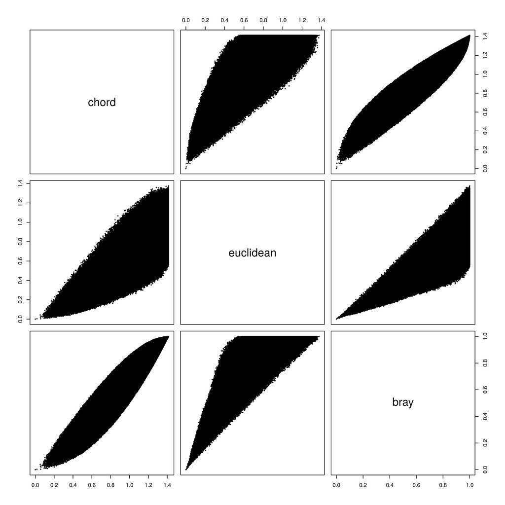

*Fig 2. Comparison of dissimilarity metrics*

```r
total.distances <- cbind(distance.all.chord, distance.all.euclid, distance.all.bray)
colnames(total.distances) <- c("chord", "euclidean", "bray")

# jpeg('~/teaching/R/distance_pairs.jpeg',height=10,width=10,units='in',res
# =300) pairs(total.distances,pch = 16,cex = 0.5) dev.off()
```

From *Fig. 2* it is clear that the euclidean distance is quite different from the two other dissimilarity metrics. Euclidean distances vary widely for large chord and Bray-Curtis distances. The Bray-Curtis distance is designed to quantify compositional dissimilarity between sites. The chord distance is the euclidean distance between square root transformed proportions. By square root transforming, all compositional vector are standardized to have a length of 1 (i.e. all these points are on the surface of a n-dimensional sphere, hence the name chord distance). The chord distance is therefore a distance metric appropriate to compare proportions whereas euclidean distances are not appropriate for compositional data.

People interested in further comparisons between Bray-Curtis and euclidean distances can work through the next section. In this section we have a closer look at samples with large Bray-Curtis but low euclidean distances. In this example, we also encounter issues with taxonomic resolution: One analyst identified * Alnus viridis subsp. crispa* whereas another analyst only identified *Alnus undiff*. You will have to set options *echo = TRUE* and *eval=TRUE* to show code and results in your output file.

## 2 The modern analogue technique

Before reconstructing an environmental variable, we usually assess how MAT performs in the modern species assemblage. This step is usually referred to as calibration

### Calibration

We will use the foraminifera data set by Imbrie and Kipp (1971) available in the *rioja* r-package by Steve Juggins. We will evaluate a MAT model for summer sea surface temperature (SumSST) using the *MAT* function from the *rioja* r-package (as default this function uses *squared chord-distances*). (I generally recommend to specify the r-package from which a function is called. For instance there are *crossval* and *performance* functions in *rioja* as well as *analogue*. The aforementioned packages also define functions *Merge* and *merge*, *MAT* and *mat* asf)

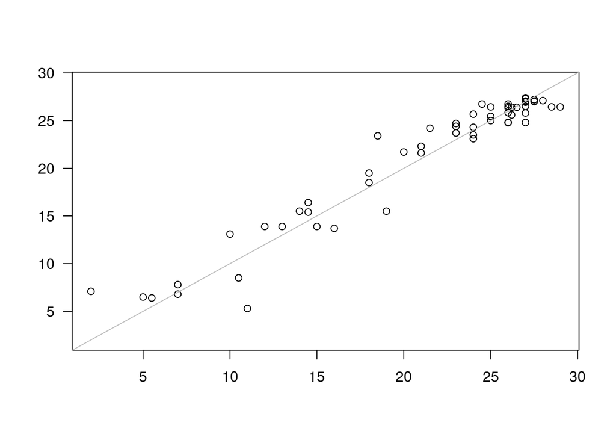

```r
data(IK)
# ?IK
spp <- IK$spec/100
fossil <- IK$core/100
sppfos <- Merge(spp, fossil, split = TRUE)
spp <- sppfos$spp
fossil <- sppfos$fossil
SumSST <- IK$env$SumSST

sumsst.mat.model <- rioja::MAT(spp, SumSST, k = 5, lean = FALSE, dist.method = "chord")
plot(sumsst.mat.model)
```

Ideally, a calibration function is trained on one portion of the modern species assemblages (calibration set) and tested on another portion of the modern species assemblages (validation set). This two data sets are mutually exclusive and hopefully independent. To validate or cross-validate MAT, we usually use a technique called k-fold cross-validation. In k-fold cross-validation the modern data set is split into *k* mutually exclusive parts. *k-1* parts are used for calibration and one part is used for validation (test).

[figure not shown]

```r
cv.sumsst.mat.model <- rioja::crossval(sumsst.mat.model, cv.method = "lgo",
    verbose = FALSE)
plot(cv.sumsst.mat.model)
```

```r
perf.cv.sumsst.mat.model <- rioja::performance(cv.sumsst.mat.model)
perf.cv.sumsst.mat.model
```

```
## $RMSE0
## [1] 7.019838
##
## $object
##            RMSE        R2    Avg.Bias Max.Bias    Skill
## N01    2.472935 0.8806064 -0.31803279 9.000000 87.59001
## N02    1.902684 0.9277029 -0.21721311 6.000000 92.65353
## N03    1.783536 0.9357997 -0.10000000 5.166667 93.54480
## N04    1.731930 0.9392722 -0.08319672 5.125000 93.91296
## N05    1.745768 0.9391509 -0.21344262 5.100000 93.81530
## N01.wm 2.472935 0.8806064 -0.31803279 9.000000 87.59001
## N02.wm 1.908583 0.9272212 -0.19868306 6.159230 92.60790
## N03.wm 1.786369 0.9356327 -0.10331394 5.468770 93.52428
## N04.wm 1.724006 0.9398568 -0.09179193 5.385207 93.96853
## N05.wm 1.742435 0.9390537 -0.18057997 5.366950 93.83889
##
## $crossval
##            RMSE        R2    Avg.Bias Max.Bias    Skill
## N01    2.444800 0.8833930 -0.23278689 9.000000 87.87079
## N02    1.866706 0.9296027 -0.10491803 6.000000 92.92873
## N03    1.801123 0.9345514 -0.13442623 5.166667 93.41687
## N04    1.772542 0.9365635 -0.08852459 5.125000 93.62414
## N05    1.719867 0.9407577 -0.16852459 5.100000 93.99746
## N01.wm 2.444800 0.8833930 -0.23278689 9.000000 87.87079
## N02.wm 1.859238 0.9302350 -0.09061145 6.159230 92.98519
## N03.wm 1.789911 0.9352796 -0.12032017 5.468770 93.49857
## N04.wm 1.754058 0.9378658 -0.08596295 5.385207 93.75642
## N05.wm 1.726667 0.9397859 -0.11890948 5.366950 93.94989
```

The code returns an object with three named components:

- RMSE0: The root mean square error when using the mean of all SumSST values instead of predicted values
- object: apparent performance statistics (all data are used for calibration)
- crossval: cross-validated performance statistics (model is tested on a hopefully independent test set)

### Reconstruction

We can apply this transfer function to foraminifera from a sediment core.

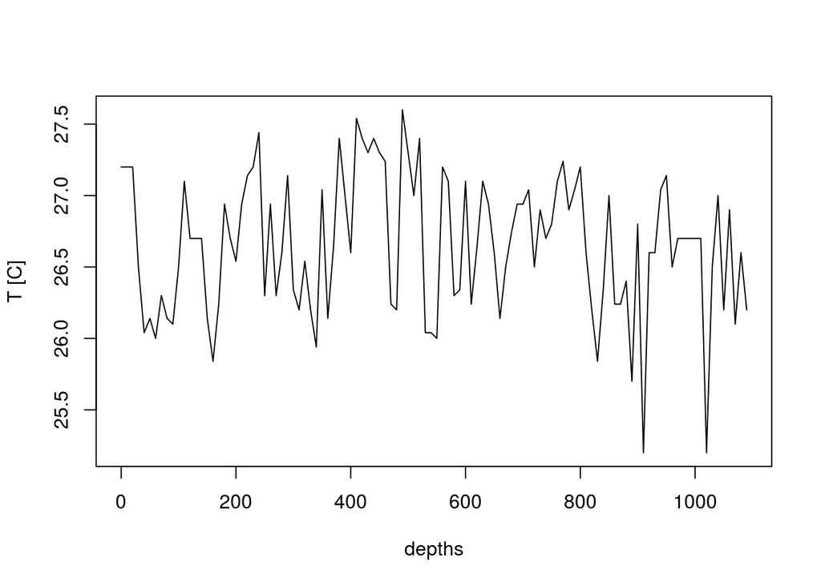

```r
depths <- as.numeric(rownames(fossil))
pred <- predict(sumsst.mat.model ,fossil)
plot(depths, pred$fit[,'MAT'],type='l',ylab ='T [C]')
```

It is crucial to assess the quality of modern analogues by looking at the dissimilarity between a fossil assemblage and the closest (least dissimilar) modern assemblage. If the shortest distance between a fossil assemblage and the modern assemblages is typical of distances between similar assemblages in the calibration set, then we can declare that the analogue match is good. The usual rule-of-thumb is that distances shorter than the 5th percentile of all distances between calibration set assemblages represent good analogues, and distances greater than the 10th percentile represent no-analogue assemblages.

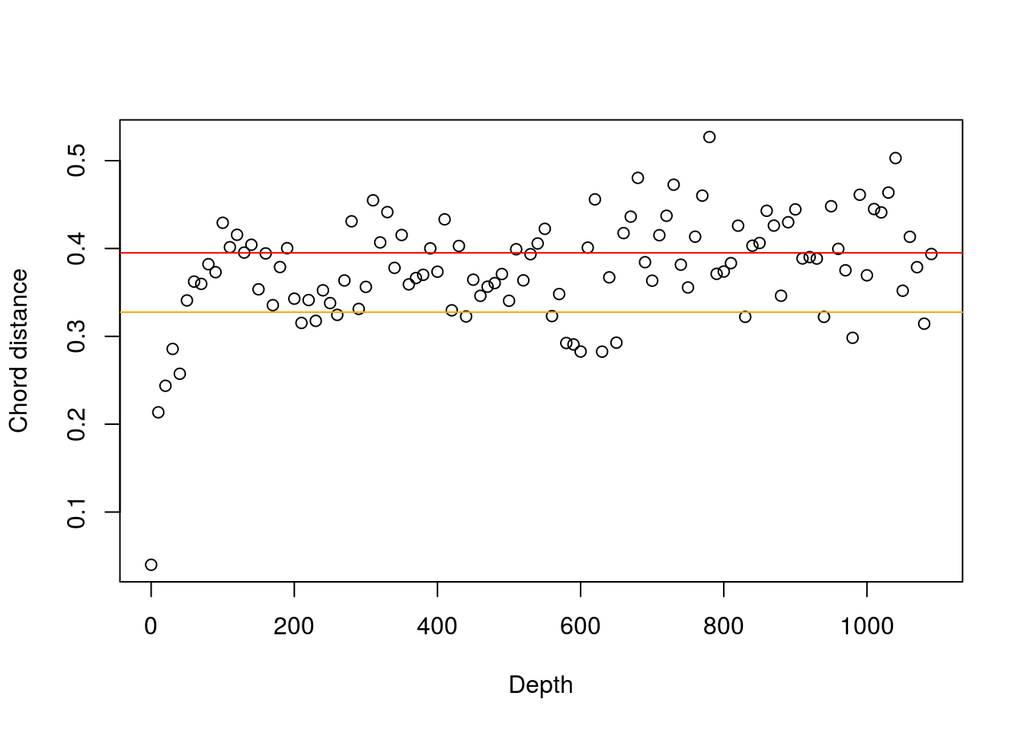

```r
goodpoorbad<-quantile(paldist(spp,dist.method='chord'), prob=c(0.05, 0.1))
plot(depths, pred$dist.n[,1], ylab="Chord distance", xlab="Depth")
abline(h=goodpoorbad, col=c("orange", "red"))
```

After assessing analogue quality we should (if possible) compare our reconstruction to other reconstructions. We can also tentatively assess the significance of our reconstruction comparing the variance of the fossil species assemblages explained by our reconstruction to the variance explained by reconstructions trained on random data.

```r
library(palaeoSig)
IKrand <- randomTF(spp = spp, env = data.frame(SumSST = SumSST),fos = fossil,fun =MAT, dist.method = 'chord',n = 999,col=1)
```

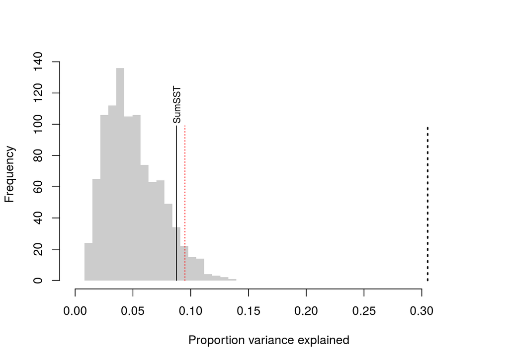

```r
plot(IKrand)
```

### How many variables can we reconstruct?

We will try to answer this question using the NAMPD.

First lets have a look at a model for temperatures of the warmest month.

```r
mat.model.mtwa <- rioja::MAT(pollen.prop,Climate$mtwa,lean=FALSE)
```

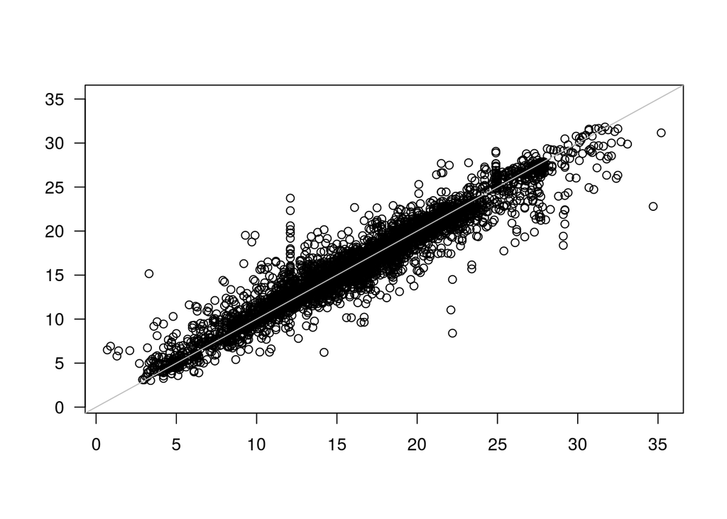

```r
#mat.model.mtwa <- rioja::MAT(sqrt(pollen.prop),as.vector(Climate$mtwa),lean=FALSE,method='euclidean')
#---------------------------------------------------------------------------------------------------------------
#curcial step: cross-validation, apply calibrate on one part of the dataset and validate on a (hopefully)
# independent dataset, with the MAT one usually uses 10-fold cross-validation
cv.mat.model.mtwa <- rioja::crossval(mat.model.mtwa,verbose=FALSE)
plot(cv.mat.model.mtwa)
```

```r
per.mat.model.mtwa <- rioja::performance(cv.mat.model.mtwa)
per.mat.model.mtwa
```

```
## $RMSE0
## [1] 5.675775
##
## $object
##            RMSE        R2    Avg.Bias Max.Bias    Skill
## N01    1.755352 0.9057596 0.009786882 2.528571 90.43515
## N02    1.585639 0.9220596 0.019635837 3.242857 92.19526
## N03    1.537631 0.9266250 0.023884406 3.695238 92.66071
## N04    1.564229 0.9240765 0.018823712 3.933929 92.40461
## N05    1.575463 0.9229897 0.016639768 3.910000 92.29511
## N01.wm 1.755352 0.9057596 0.009786882 2.528571 90.43515
## N02.wm 1.562163 0.9243370 0.016671005 3.183174 92.42466
## N03.wm 1.507905 0.9294337 0.021232569 3.632620 92.94174
## N04.wm 1.519929 0.9283328 0.017950688 3.853938 92.82873
## N05.wm 1.526585 0.9277150 0.015305734 3.813363 92.76578
##
## $crossval
##            RMSE        R2    Avg.Bias Max.Bias    Skill
## N01    1.784647 0.9027192 0.001634595 3.157143 90.11323
## N02    1.601310 0.9204941 0.015176909 3.407143 92.04023
## N03    1.560736 0.9243960 0.018725429 3.638095 92.43849
## N04    1.578983 0.9226134 0.010180012 4.073214 92.26064
## N05    1.580743 0.9224636 0.012911235 3.967143 92.24338
## N01.wm 1.784647 0.9027192 0.001634595 3.157143 90.11323
## N02.wm 1.578686 0.9227114 0.010170224 3.356447 92.26356
## N03.wm 1.531042 0.9272414 0.013901175 3.610313 92.72348
## N04.wm 1.531938 0.9271699 0.009205260 3.958917 92.71496
## N05.wm 1.528628 0.9275180 0.011034893 3.860680 92.74640
```

This model is excellent! We can assess performances of models for all variables given in the *Climate* data set.

```r
# mat.model <- lapply(colnames(Climate),function(x){
#   rioja::MAT(pollen.prop,as.vector(Climate[,x]),lean=FALSE)
# })
#
# names(mat.model) <- colnames(Climate)
#
# crossval.mat <- lapply(names(mat.model),function(x){
#   rioja::crossval(mat.model[[x]],verbose=FALSE)
# })
#
# names(crossval.mat) <- colnames(Climate)
#
# perf.mat <- lapply(names(mat.model),function(x){
#   rioja::performance(crossval.mat[[x]])
# })
#
# names(perf.mat) <- colnames(Climate)
#
# saveRDS(perf.mat,'/data/calibration_MAT_RDS')

perf.mat <- readRDS('/home/mathias/teaching_uploads/data/calibration_MAT_RDS')
perf.mat
```

```
## $tjan
## $tjan$RMSE0
## [1] 11.16993
##
## $tjan$object
##            RMSE        R2  Avg.Bias Max.Bias    Skill
## N01    3.076891 0.9258860 0.1689841 1.958333 92.41207
## N02    2.946997 0.9313403 0.2311711 2.387917 93.03921
## N03    2.826226 0.9368197 0.2866956 2.637222 93.59804
## N04    2.906407 0.9330778 0.2964773 2.790417 93.22964
## N05    2.933883 0.9317542 0.2992262 2.852000 93.10103
## N01.wm 3.076891 0.9258860 0.1689841 1.958333 92.41207
## N02.wm 2.882170 0.9342716 0.2159023 2.289749 93.34208
## N03.wm 2.751688 0.9400345 0.2638521 2.506775 93.93128
## N04.wm 2.798213 0.9379220 0.2759178 2.641686 93.72432
## N05.wm 2.814062 0.9371861 0.2808181 2.699517 93.65303
##
## $tjan$crossval
##            RMSE        R2  Avg.Bias Max.Bias    Skill
## N01    3.115414 0.9240196 0.1607076 1.884167 92.22088
## N02    2.953643 0.9310549 0.2485206 2.345417 93.00778
## N03    2.897135 0.9334742 0.2748948 2.775833 93.27277
## N04    2.941325 0.9313973 0.2880923 2.722083 93.06598
## N05    2.973198 0.9299333 0.3099979 2.825333 92.91489
## N01.wm 3.115414 0.9240196 0.1607076 1.884167 92.22088
## N02.wm 2.894691 0.9337268 0.2334509 2.232874 93.28411
## N03.wm 2.809275 0.9374080 0.2577405 2.609394 93.67461
## N04.wm 2.829460 0.9364831 0.2704974 2.586257 93.58338
## N05.wm 2.845817 0.9357756 0.2902465 2.686562 93.50898
##
##
## $tfeb
## $tfeb$RMSE0
## [1] 11.47877
##
## $tfeb$object
##            RMSE        R2  Avg.Bias Max.Bias    Skill
## N01    3.046780 0.9311988 0.1617836 1.762319 92.95483
## N02    2.918202 0.9362220 0.2107904 2.439655 93.53691
## N03    2.797258 0.9413510 0.2649286 2.420690 94.06153
```

[output cut: 935 more lines]

```
## N04.wm 196.5523 0.8327218 12.737630 1318.403 83.16028
## N05.wm 195.8526 0.8337577 13.878626 1325.542 83.27996
##
## $annp$crossval
##            RMSE        R2  Avg.Bias Max.Bias    Skill
## N01    231.4324 0.7765021  8.515001 2019.000 76.65323
## N02    206.3402 0.8169038 12.588144 1795.000 81.44135
## N03    205.2914 0.8178761 14.860749 1350.556 81.62954
## N04    205.8103 0.8166438 15.762156 1195.300 81.53655
## N05    205.5960 0.8170185 17.027974 1298.000 81.57498
## N01.wm 231.4324 0.7765021  8.515001 2019.000 76.65323
## N02.wm 204.3223 0.8204365 11.577526 1822.439 81.80256
## N03.wm 200.5051 0.8261763 13.311417 1438.541 82.47616
## N04.wm 199.4883 0.8276209 14.070813 1283.601 82.65342
## N05.wm 198.3264 0.8295646 15.165960 1369.167 82.85491
```

Can we really reconstruct 32 variables? Probably not! Why could 32 variables seem reconstructable?

- spatial correlation between variables (does not mean there is a temporal correlation)
- spatial autocorrelation

**To obtain a good reconstruction, we should first ask the question: does this reconstruction make sense ecologically?**

### Spatial autocorrelation

Environmental variables influencing species composition are often spatially autocorrelated (e.g. summer temperatures at spatially close locations are more similar than summer temperatures at spatially distant locations). This is not in itself a problem. If an environmental variable influencing species assemblages is spatially autocorrelated, spatially close assemblages tend to be similar. The similarity of spatially close assemblages in turn means that sites chosen as analogues are spatially close. This again means that any spatially autocorrelated variable will perform well under cross-validation, even if it is globally unrelated to the variable influencing species assemblages. As an example, we can evaluate the performance of a model for an (obviously nonsensical) variable: distance to Calgary:

```r
library(fields)
coord.calgary <- matrix(c(-114, 51), ncol = 2)

dist.calgary <- t(rdist.earth(coord.calgary, cbind(lon, lat)))

cor.env.var <- round(cor(dist.calgary, Climate), 2)
print(cor.env.var)
```

```
##       tjan  tfeb  tmar  tapr  tmay  tjun  tjul  taug  tsep  toct tnov
## [1,] -0.06 -0.14 -0.13 -0.12 -0.08 -0.05 -0.08 -0.09 -0.04 -0.07 0.01
##       tdec  pjan pfeb pmar papr pmay pjun pjul paug psep poct pnov  pdec
## [1,] -0.02 -0.05 0.02 0.07 0.18 0.25 0.32 0.48 0.55 0.42 0.19 0.03 -0.03
##       tave  tmax tmin gdd0 gdd5  mtco  mtwa annp
## [1,] -0.08 -0.35 0.17 0.05  0.1 -0.07 -0.08 0.21
```

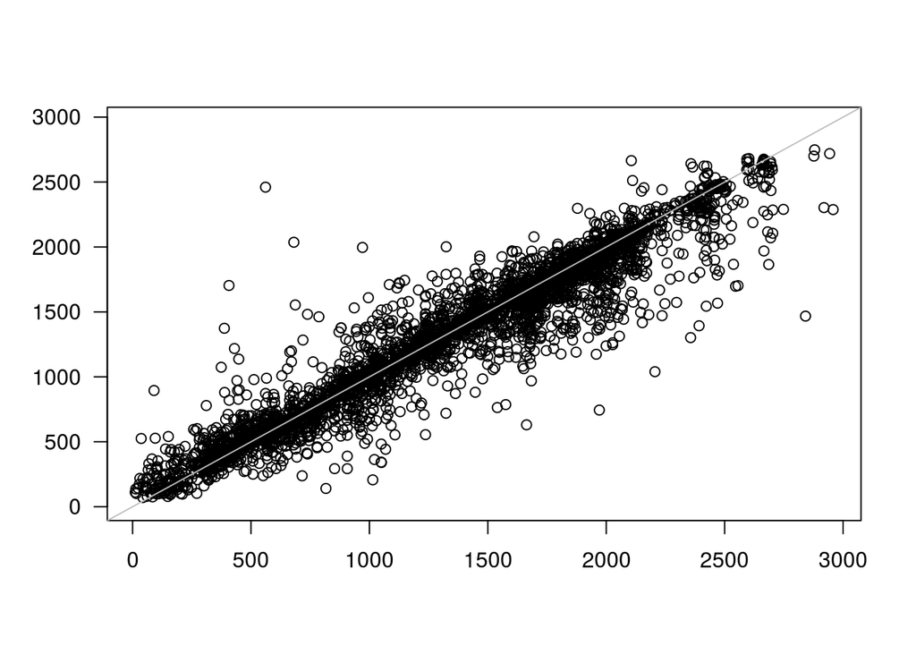

```r
mat.calgary <- rioja::MAT(y = pollen.prop, dist.calgary, lean = FALSE)
cv.calgary <- rioja::crossval(mat.calgary, verbose = FALSE)
perf.calgary <- rioja::performance(cv.calgary)
plot(cv.calgary)
```

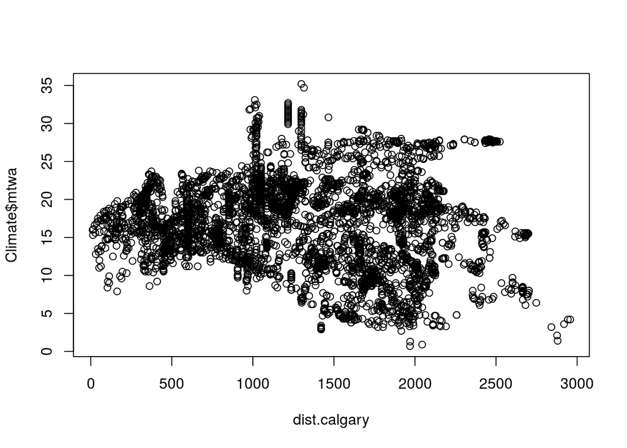

```r
plot(dist.calgary, Climate$mtwa)
```

It is possible to assess the influence of spatial autocorrelation using h-block cross-validation. Under h-block cross-validation samples within radius *h* of the predicted sample are removed from the calibration data set. One problem of h-block cross-validation is that we one the one hand account for artificial skill caused by spatial autocorrelation but on the other hand remove taxonomically close modern analogues also removing true skill.

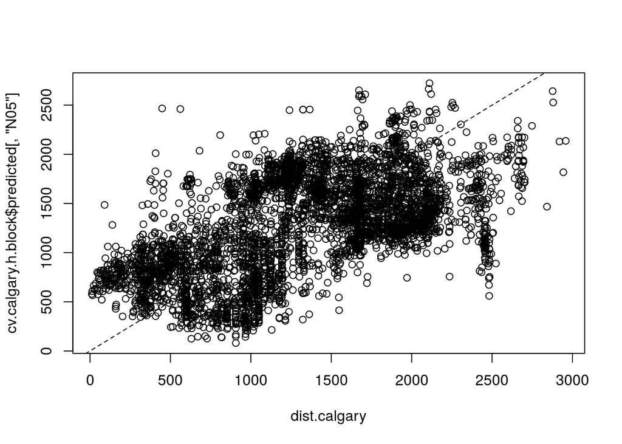

```r
dist.h <- rdist.earth(cbind(lon,lat),cbind(lon,lat))
cv.calgary.h.block <- rioja::crossval(mat.calgary,h.cutoff = 500,h.dist=dist.h,cv.method = 'h-block',verbose=FALSE)
plot(dist.calgary,cv.calgary.h.block$predicted[,'N05'])
abline(a=0,b=1,lty=2)
```

```r
rioja::performance(cv.calgary.h.block)
```

```
## $RMSE0
## [1] 604.8569
##
## $object
##            RMSE        R2  Avg.Bias Max.Bias    Skill
## N01    175.4432 0.9176049  9.581908 165.7415 91.58667
## N02    167.6362 0.9242311 16.143352 221.5481 92.31878
## N03    161.6631 0.9294875 18.234972 223.5527 92.85641
## N04    164.4657 0.9270958 19.411634 252.9188 92.60658
## N05    166.8169 0.9250363 19.891359 268.2763 92.39368
## N01.wm 175.4432 0.9176049  9.581908 165.7415 91.58667
## N02.wm 163.6981 0.9276830 15.294183 204.4796 92.67543
## N03.wm 156.6030 0.9337991 17.315141 204.5877 93.29660
## N04.wm 158.1477 0.9325818 18.589418 230.2196 93.16371
## N05.wm 159.2890 0.9316778 19.186584 244.6036 93.06468
##
## $crossval
##            RMSE        R2 Avg.Bias  Max.Bias     Skill
## N01    575.8696 0.2793825 39.72114  922.8722  9.355194
## N02    545.2385 0.3043462 43.54507  949.2802 18.741693
## N03    535.8628 0.3112115 44.65952  967.8120 21.512258
## N04    531.1431 0.3137231 45.07971  988.0042 22.888739
## N05    528.8426 0.3145171 45.24624 1003.5614 23.555281
## N01.wm 575.8696 0.2793825 39.72114  922.8722  9.355194
## N02.wm 544.6903 0.3057529 43.08618  945.4103 18.905027
## N03.wm 534.9175 0.3134133 44.12037  962.6767 21.788926
## N04.wm 530.0455 0.3163700 44.76910  981.6480 23.207104
## N05.wm 527.5792 0.3174565 44.96458  996.3462 23.920075
```

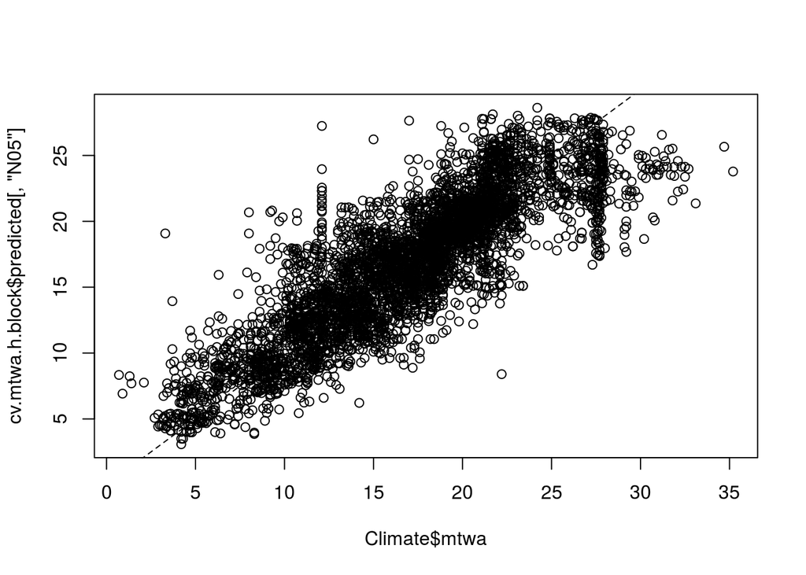

```r
#-------------------------------------------------------------------------------------------------------------------
#compare this to h-block cross-validation of the mtwa model
cv.mtwa.h.block <- rioja::crossval(mat.model.mtwa,h.cutoff = 500,h.dist=dist.h,cv.method = 'h-block',verbose=FALSE)
plot(Climate$mtwa,cv.mtwa.h.block$predicted[,'N05'])
abline(a=0,b=1,lty=2)
```

```r
rioja::performance(cv.mtwa.h.block)
```

```
## $RMSE0
## [1] 5.675775
##
## $object
##            RMSE        R2    Avg.Bias Max.Bias    Skill
## N01    1.755352 0.9057596 0.009786882 2.528571 90.43515
## N02    1.585639 0.9220596 0.019635837 3.242857 92.19526
## N03    1.537631 0.9266250 0.023884406 3.695238 92.66071
## N04    1.564229 0.9240765 0.018823712 3.933929 92.40461
## N05    1.575463 0.9229897 0.016639768 3.910000 92.29511
## N01.wm 1.755352 0.9057596 0.009786882 2.528571 90.43515
## N02.wm 1.562163 0.9243370 0.016671005 3.183174 92.42466
## N03.wm 1.507905 0.9294337 0.021232569 3.632620 92.94174
## N04.wm 1.519929 0.9283328 0.017950688 3.853938 92.82873
## N05.wm 1.526585 0.9277150 0.015305734 3.813363 92.76578
##
## $crossval
##            RMSE        R2   Avg.Bias Max.Bias    Skill
## N01    3.497870 0.6533017 0.03283675 8.614286 62.01982
## N02    3.155842 0.7034730 0.08319884 8.432143 69.08422
## N03    3.054308 0.7181089 0.09344782 8.838095 71.04154
## N04    2.997853 0.7265545 0.10683323 8.889286 72.10217
## N05    2.957338 0.7326645 0.09527002 9.044286 72.85113
## N01.wm 3.497870 0.6533017 0.03283675 8.614286 62.01982
## N02.wm 3.156126 0.7034911 0.08098981 8.419107 69.07865
## N03.wm 3.053097 0.7184444 0.09094883 8.765084 71.06451
## N04.wm 2.995682 0.7270433 0.10377125 8.814812 72.14256
## N05.wm 2.953507 0.7334150 0.09479722 8.971644 72.92143
```

Using h-block cross-validation, we can confirm that mean temperature of the warmest month is an ecologically meaningful variable whereas distance to Calgary does not influence pollen assemblages.

If you are interested in effects of spatial autocorrelation on transfer function performance and how to detect spatial autocorrelation you can work through some examples of the *palaeoSig* r-package by Richard Telford.

```r
library(palaeoSig)
?rne
```